# Political activity - Voting

# 1 Description of DataSchema variable

The description of harmonised variable is the following:

- Short name: `pol_vot`
- Variable label: `Voting?`
- Variable description: `Political activity - voting`
- Domain: `Social environment`
- Value type: `categorical`
- Category coding:

| **Code** | **Category Label** |
| --- | --- |
| 0 | No |
| 1 | Yes |

- Category missings:

| **Code** | **Category Label** |
| --- | --- |
| 991 | CAPI/interviewer error |
| 992 | Impute |
| 993 | Disable to measure |
| 994 | Not attempt/not done |
| 995 | Does not answer |
| 996 | Not applicable |
| 997 | Refuse |
| 998 | Do not know |
| 999 | Missing |

# 2 Data process

## 2.1 England

### 2.1.1 Wave 1

#### 2.1.1.1 Study-specific variable description

| **Name** | `scptpa1` |
| --- | --- |
| **Label** | `Which of these statements apply to you: "I voted in the last general election."?` |
| **Table name** | `wave_1_core_data_v3` |
| **Categories** | `1 = Yes` `0 = No` |
| **Missings** | `-9 = Not answered` `-1 = Item not applicable` |
| **Description** |  |

scptpa1

| Sample size | Missing values |
| --- | --- |
| 12099 | 1175 |

Category

|  | 0 | 1 |
| --- | --- | --- |
| Frequency | 1900.0 | 9024.00 |
| Percentage | 15.7 | 74.58 |

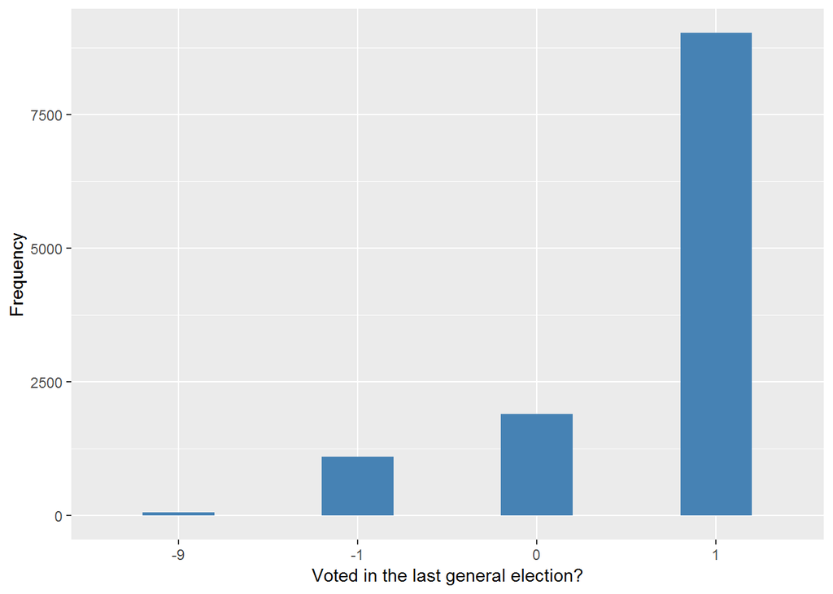

#### 2.1.1.2 Harmonisation algorithm

To compute the harmonize variable from the study-specific variable it has to be recoded as follows:

- `1 into 1, 0 into 0`
- `-1 into 996`
- `-9 into 995`
- `NA into 999`

**R script:**

```r
ELSA_ds_w1 <- tibble(id = ELSA_w1$id)
ELSA_ds_w1$pol_vot <- car::recode(as.vector(ELSA_w1$scptpa1), "0='0'; 1='1'; -1='996'; -9='995'; NA='999'")
```

#### 2.1.1.3 Statistics of the new harmonised variable

Political activity - voting

| Sample size | Missing values |
| --- | --- |
| 12099 | 1175 |

Category

|  | 0 | 1 |
| --- | --- | --- |
| Frequency | 1900.0 | 9024.00 |
| Percentage | 15.7 | 74.58 |

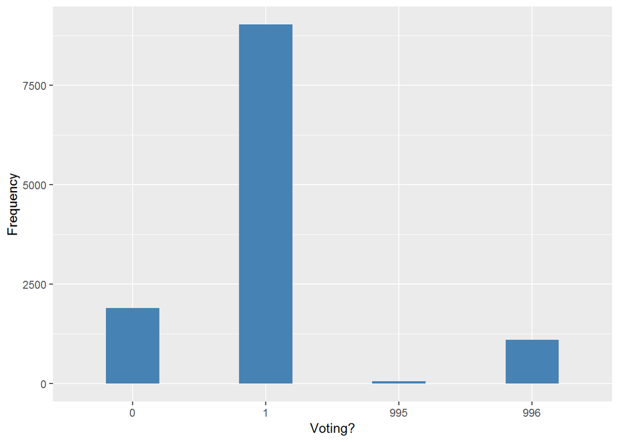

#### 2.1.1.4 Validation

|  | 0 | 1 | -9->995 | -1->996 |
| --- | --- | --- | --- | --- |
| BeforeH | 1900 | 9024 | 67 | 1108 |
| AfterH | 1900 | 9024 | 67 | 1108 |

### 2.1.2 Wave 2

Not found.

### 2.1.3 Wave 3

#### 2.1.3.1 Study-specific variable description

| **Name** | `scpt01` |
| --- | --- |
| **Label** | `Respondent voted in the last General Election` |
| **Table name** | `wave_3_elsa_data_v4` |
| **Categories** | `1 = Yes` `0 = No` |
| **Missings** | `-9 = Not answered` `-8 = Don't know` `-1 = Item not applicable` |
| **Description** |  |

scpt01

| Sample size | Missing values |
| --- | --- |
| 9771 | 1668 |

Category

|  | 0 | 1 |
| --- | --- | --- |
| Frequency | 1242.00 | 6861.00 |
| Percentage | 12.71 | 70.22 |

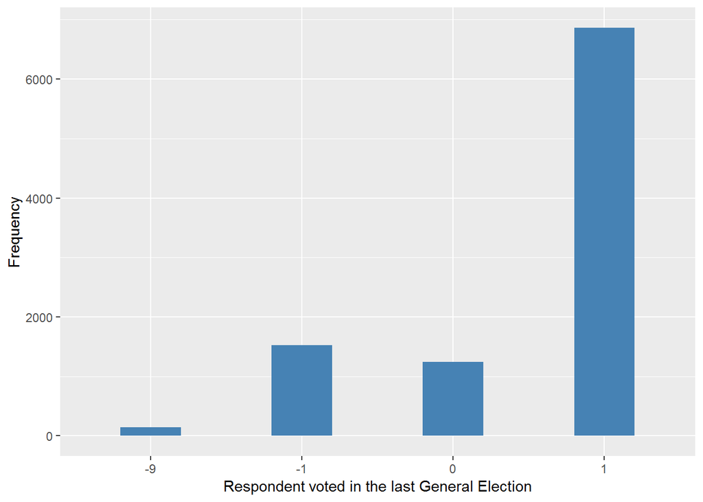

#### 2.1.3.2 Harmonisation algorithm

To compute the harmonize variable from the study-specific variable it has to be recoded as follows:

- `1 into 1, 0 into 0`
- `-1 into 996`
- `-8 into 998`
- `-9 into 995`
- `NA into 999`

**R script:**

```r
ELSA_ds_w3 <- tibble(id = ELSA_w3$id)
ELSA_ds_w3$pol_vot <- car::recode(as.vector(ELSA_w3$scpt01), "1='1'; 0='0'; -1='996'; -8='998'; -9='995'; NA='999'")
```

#### 2.1.3.3 Statistics of the new harmonised variable

Political activity - voting

| Sample size | Missing values |
| --- | --- |
| 9771 | 1668 |

Category

|  | 0 | 1 |
| --- | --- | --- |
| Frequency | 1242.00 | 6861.00 |
| Percentage | 12.71 | 70.22 |

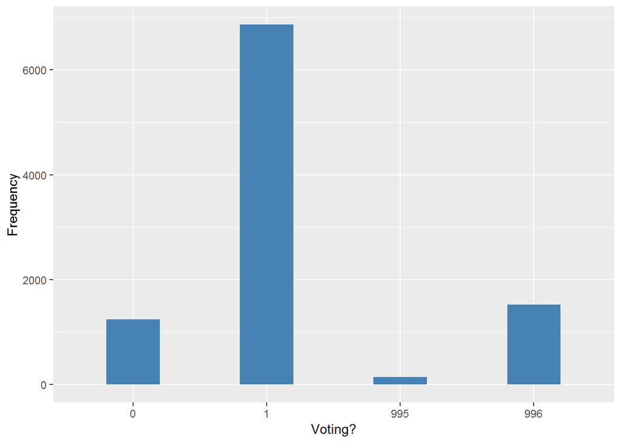

#### 2.1.3.4 Validation

|  | 0 | 1 | -9->995 | -1->996 |
| --- | --- | --- | --- | --- |
| BeforeH | 1242 | 6861 | 141 | 1527 |
| AfterH | 1242 | 6861 | 141 | 1527 |

### 2.1.4 Wave 4

Not found.

### 2.1.5 Wave 5

Not found.

### 2.1.6 Wave 6

Not found.

### 2.1.7 Wave 7

Not found.

## 2.2 Summary of descriptive statistics of the harmonised variable accross populations and waves

Two tables are generated:

1. Percentages of categories in each harmonised variable.
2. Frequencies and percentages of individuals with different trajectories.

Political activity - voting

| val | label | W1 | W3 |
| --- | --- | --- | --- |
| 0 | No | 15.7 | 12.71 |
| 1 | Yes | 74.58 | 70.22 |
| 991 | CAPI interviewer error | 0 | 0 |
| 992 | Impute | 0 | 0 |
| 993 | Disable to measure | 0 | 0 |
| 994 | Not attempt not done | 0 | 0 |
| 995 | Does not answer | 0.55 | 1.44 |
| 996 | Not applicable | 9.16 | 15.63 |
| 997 | Refuse | 0 | 0 |
| 998 | Do not know | 0 | 0 |
| 999 | Missing | 0 | 0 |
| NA | NA | 0 | 0 |
| n | sample size | 12099 | 9771 |

| val | frq | raw.prc |
| --- | --- | --- |
| 00 | 496 | 3.57 |
| 01 | 501 | 3.61 |
| 0NA | 903 | 6.50 |
| 10 | 381 | 2.74 |
| 11 | 5119 | 36.84 |
| 1NA | 3524 | 25.36 |
| NA0 | 365 | 2.63 |
| NA1 | 1241 | 8.93 |
| NANA | 1364 | 9.82 |
| NA | 0 | 0.00 |

# 3 Quality estimation